# MarkerPaperMetaAnalysis_Natives

Amanda Charbonneau

January 21, 2015

### Are there differences in DTF among native subspecies of *R. raphanistrum*?

*R. raphanistrum* is native to the area around the Mediterranean, and it has been suggested that it originated on the western side where Raphanus diversity is highest. We have *R. raphanistrum* populations from three subspecies: *R.r. maritimus*, *R.r. landra* and *R.r. raphanistrum* as well as two other closely related and co-localizing *Raphanus* species: *R. confusus* and *R. rostratus*. We want to test both whether there is a difference in flowering time between native sub-species, and if there is, whether the *R. raphanistrum* sub-species are more similar to each other, or to other *Raphanus* species that are co-localized.

### Models for native *Raphanus*

We want to model days to flowering as a function of SubSpecies. As our data sets were done at different times and places, we want to account for all known sources of variation caused by differences in experimental design. To start, all our models have the same basic fixed and random effects:

#### Fixed Effects

**Geography** allows for each geographic group (east, west and non-native) to have its own intercept

**Seedstock** captures the variation in flowering time due to parental growth environment. Since most populations only have a single parental growth environment, this should only see the effect of the qtl2004 populations, which were all propagated from qtl2003 and lale2005 populations which were propagated from qtl2004.

**GrowthEnvironment** accounts for variation due to the study plant being growth in the greenhouse or field

**DOYGS** (Day of year germinated, standardized) OR **DOYPS** (Day of year planted, standardized) accounts for variation in seasons, as experiments were started at different times of year and so experienced differing growth conditions like length of day and light intensity. We don’t have germination date for all plants, but know that some have a gap of weeks-months between germ and flower dates. The ‘standardization’ is subtracting 78 from each value, then adding 365 to values less than zero, so that all the winter days are together.

**Habitat** accounts for variation due to type of micro-habitat that each population was collected from and may be locally adapted to

**DaysVernNoNA** accounts for whether an individual was vernalized, and for how long

The interaction term **GrowthEnvironment:Geography** allows populations from each geographic region to have independent reactions to **GrowthEnvironment**

#### Random Effects

The **Geography**|**Experiment** term accounts for apparent variance among population means due to **Geography** that may be due to differences between **Experiment**s

The **Geography**:**Pop** term finds the variance among population means within each geographic region

Before running the models, here are graphs looking at the data I’m going to use to make sure everything looks like it’s imported correctly and to see if any variables look bad (too many NA’s, weird data points, etc.)

##### Response variable

We are modeling days to flowering as the response variable, but we have two different versions of this: **PTF** is planting to flower, which is the amount of time it took from putting the seed in soil until the subsequent plant first flowered. We also have **GTF**, which is germination to flowering. This is the amount of time from when the seedling first emerged from the soil until the plant flowered. Although these are very similar, only one, **PTF**, was recorded in all experiments, however for the experiments where both were recorded many individuals had very large lag times between planting and germination, with a range of 3 to 142 for both the data set as a whole, and just the native subset. (The individual that took 142 days was an MAES.)

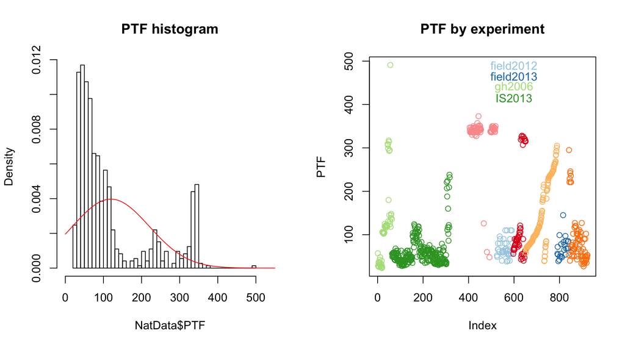

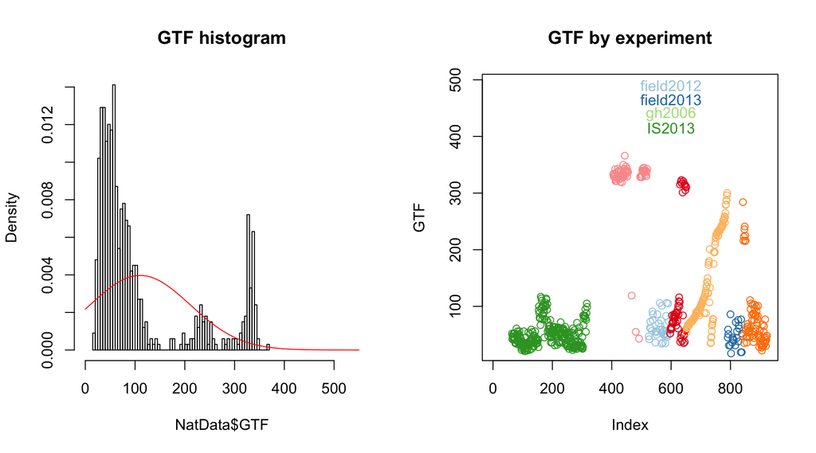

[output not shown]

##### Predictor variables

These are plots of each predictor variable against the response. For each I have plotted against **PTF** on the left and against **GTF** on the right.

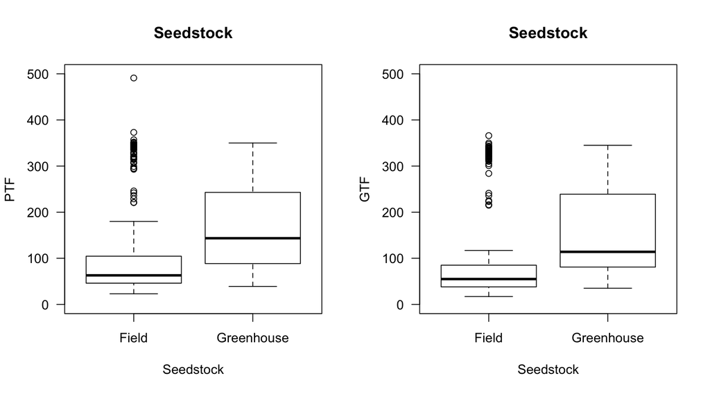

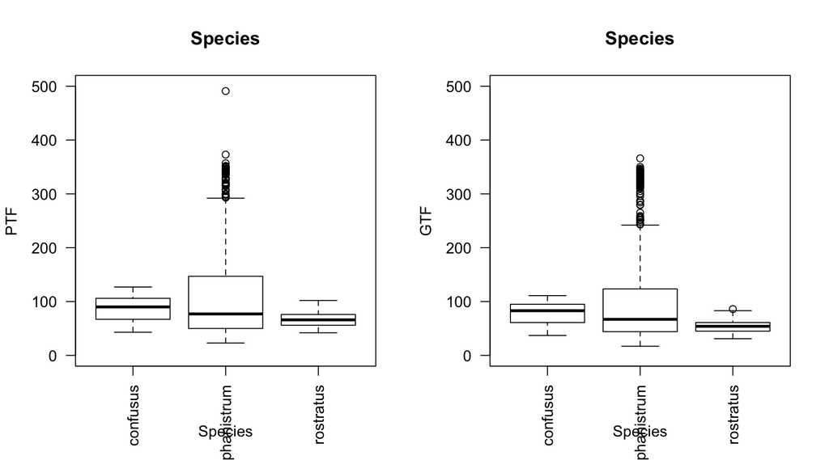

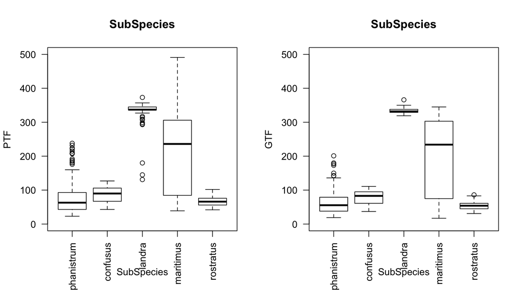

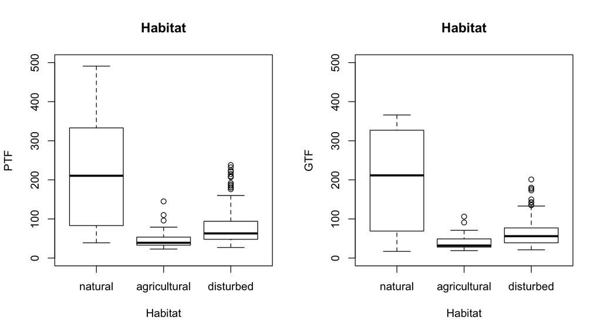

[output not shown]

#### Modeling

These models all originally included **DOYGS** as a predictor, but it had zero effect to three decimal places, so I dropped it to increase the DoF available to fit other parameters

##### Model 1

This is the model that is roughly equivalent to the model we used to look at the differences between the *R.r. raphanistrum* plants, just using **SubSpecies** instead of **Geography**

```r
Nat_lmer_1 <- lmer( GTF ~ SubSpecies + Seedstock + GrowthEnvironment + DaysVernNoNA + GrowthEnvironment:SubSpecies + (1|Experiment) + (1|SubSpecies:Pop), data=NatDataGTF  )
```

```
## fixed-effect model matrix is rank deficient so dropping 1 column / coefficient
```

##### Model 2

Model 1, but dropping AFFR since I could probably justify dropping it from the natives data set

```r
Nat_lmer_2 <- lmer( GTF ~ SubSpecies + Seedstock + GrowthEnvironment + DaysVernNoNA + GrowthEnvironment:SubSpecies + (1|Experiment) + (1|SubSpecies:Pop), data=NoAFFRGTF  )
```

```
## fixed-effect model matrix is rank deficient so dropping 1 column / coefficient
```

##### Model 3

Model 1, but dropping GMIL and NZIL as I could justify dropping them since they’re different species

```r
Nat_lmer_3 <- lmer( GTF ~ SubSpecies + Seedstock + GrowthEnvironment + DaysVernNoNA + GrowthEnvironment:SubSpecies + (1|Experiment) + (1|SubSpecies:Pop), data=JustRrsGTF )
```

```
## fixed-effect model matrix is rank deficient so dropping 1 column / coefficient
```

##### Model 4

Model 1, but dropping AFFR, GMIL and NZIL

```r
Nat_lmer_4 <- lmer( GTF ~ SubSpecies + Seedstock + GrowthEnvironment + DaysVernNoNA + GrowthEnvironment:SubSpecies + (1|Experiment) + (1|SubSpecies:Pop), data=CanonNatGTF )
```

```
## fixed-effect model matrix is rank deficient so dropping 1 column / coefficient
```

##### Model 5

Model 1, but dropping **GrowthEnvironment:SubSpecies**

```r
Nat_lmer_5 <- lmer( GTF ~ SubSpecies + Seedstock + GrowthEnvironment + DaysVernNoNA + (1|Experiment) + (1|SubSpecies:Pop), data=NatDataGTF  )
```

##### Model 6

This is the model that is roughly equivalent to the model we used to look at the differences between the *R.r. raphanistrum* plants, just using **SubSpecies** instead of **Geography**, and using the new **SurviveGTF** response

```r
Nat_lmer_6 <- lmer( SurviveGTF ~ SubSpecies + Seedstock + GrowthEnvironment + DaysVernNoNA + GrowthEnvironment:SubSpecies + (1|Experiment) + (1|SubSpecies:Pop), data=NatDataSurvive  )
```

```
## fixed-effect model matrix is rank deficient so dropping 1 column / coefficient
```

##### Model 7

Model 1, but dropping **GrowthEnvironment:SubSpecies** and using the new **SurviveGTF** response

```r
Nat_lmer_7 <- lmer( SurviveGTF ~ SubSpecies + Seedstock + GrowthEnvironment + DaysVernNoNA + (1|Experiment) + (1|SubSpecies:Pop), data=NatDataSurvive  )
```

##### Model 8

This is the model that is roughly equivalent to the model we used to look at the differences between the *R.r. raphanistrum* plants, just using **SubSpecies** instead of **Geography**, and using the new **SurviveGTF** response. Dropped **GrowthEnvironment** as in Rrr_lmer_14

```r
Nat_lmer_8 <- lmer( SurviveGTF ~ SubSpecies + Seedstock + DaysVernNoNA + (1|Experiment) + (1|SubSpecies:Pop), data=NatDataSurvive  )
```

#### Notes

[output not shown]

#### Model Results

##### (these models didn’t fit ‘correctly’, LMER fit fewer terms than I asked for)

| **Fixed Effects** (std.err) | M1: AllNat | M2: NoAFFR | M3: JustRrs | M4: CanonNat | M5: DropGE:SS | M6: AllNatSurvive | M7:DropGE:SS Survive | M8:Drop GE, Survive |
| --- | --- | --- | --- | --- | --- | --- | --- | --- |
| SS. raph | 54.6 (9.27) | 58.6 (10.69) | 54.4 (9.47) | 59 (10.83) | 26.7 (15.38) | 87.9 (11.88) | 72.9 (12.72) | 59 (10.61) |
| SS. NZIL | -1.4 (23.84) | -3.2 (24.98) | NA | NA | 30.8 (20.15) | -16.5 (24.68) | 12.2 (21.63) | 11.2 (21.9) |
| SS. landra | 33.7 (20.66) | 30.1 (21.41) | 33.8 (20.79) | 29.8 (21.51) | 83.8 (21.16) | 97.1 (20.66) | 113.3 (21.64) | 115.6 (21.87) |
| SS. mari | -7.5 (15.78) | -11.2 (17.24) | -7.4 (15.9) | -11.5 (17.36) | 31.3 (15.19) | 31.8 (15.87) | 56.6 (16.19) | 56.4 (16.4) |
| SS. GMIL | -1.9 (19.84) | -6.2 (21.05) | NA | NA | 9 (19.91) | -34.2 (22.01) | -14.4 (21.61) | -14.2 (21.85) |
| GroEnvirGreenhouse | -7.3 (8.71) | -9.8 (9.38) | -7.2 (8.98) | -10.1 (9.54) | 24.8 (18.27) | -45.3 (12.55) | -23 (13.5) | NA |
| SeedstockGreenhouse | 27.7 (7.42) | 28.6 (7.67) | 27.8 (7.61) | 28.7 (7.74) | 36.7 (10.22) | 57.8 (9.69) | 60 (10.23) | 62.7 (10.74) |
| DaysVernNoNA | 1.7 (0.05) | 1.7 (0.05) | 1.7 (0.05) | 1.7 (0.05) | 1.7 (0.05) | 1.1 (0.05) | 1.1 (0.05) | 1.1 (0.05) |
| SS. NZIL GH | 40.8 (17.08) | 40.6 (17.72) | NA | NA | NA | 48.2 (19.73) | NA | NA |
| SS. mari GH | 58.8 (8.68) | 61 (9.55) | 58.7 (8.91) | 61.3 (9.8) | NA | 47.9 (8.1) | NA | NA |
| SS. GMIL GH | 16 (12.1) | 18.3 (12.77) | NA | NA | NA | 40.6 (18.22) | NA | NA |

| **Random Effects** std.dev | M1: AllNat | M2: NoAFFR | M3: JustRrs | M4: CanonNat | M5: DropGE:SS | M6: AllNatSurvive | M7:DropGE:SS Survive | M8:Drop GE, Survive |
| --- | --- | --- | --- | --- | --- | --- | --- | --- |
| SubSpecies:Pop | 17.11 | 17.42 | 17.1 | 17.38 | 17.79 | 17.25 | 18.36 | 18.57 |
| Experiment | 8.49 | 7.73 | 8.76 | 7.7 | 23.44 | 14.7 | 16.79 | 20.28 |

```
## fixed-effect model matrix is rank deficient so dropping 1 column / coefficient
## fixed-effect model matrix is rank deficient so dropping 1 column / coefficient
```

```
## Computing profile confidence intervals ...
```

I can present mean flowering time per population in two different ways. Either with a mean for each population averaged across greenhouse and field experiments, or with a different mean for plants grown in field experiments than in greenhouse experiments. We’ve agreed that it will be most useful to have means for field and greenhouse populations.

| **Pop** | **GE** | **Geo** | **GTFN** | **SGTFN** | **StrMeanGTF** | **StrMeanSur** | **M1_Mean** | **M5_Mean** | **M6_Mean** | **M7_Mean** |
| --- | --- | --- | --- | --- | --- | --- | --- | --- | --- | --- |
| AFFR | field | west | 13 | 14 | 46.5 | 50.8 | 61.9 | 44.4 | 78.1 | 64.5 |
| AFFR | greenhouse | west | 30 | 30 | 36.7 | 36.7 | 46.8 | 54 | 69.3 | 75.6 |
| CBES | field | west | 5 | 13 | 59.8 | 136 | 30.1 | 47.7 | 105.4 | 114.3 |
| CBES | greenhouse | west | 10 | 10 | 193.9 | 193.9 | 65.5 | 57.3 | 136.5 | 125.4 |
| DEES | greenhouse | west | 30 | 30 | 92.8 | 92.8 | 103.2 | 102.8 | 132.4 | 131.1 |
| HCES | greenhouse | west | 30 | 30 | 54.3 | 54.3 | 67.3 | 67.3 | 99.5 | 99.4 |
| HMES | greenhouse | west | 30 | 30 | 52.9 | 52.9 | 65.9 | 66 | 98.3 | 98.2 |
| IMES | greenhouse | west | 30 | 30 | 37.8 | 37.8 | 51.8 | 52 | 85.4 | 85.8 |
| MAES | field | west | 11 | 73 | 71.5 | 146.8 | 60.5 | 37.9 | 86.1 | 73.4 |
| MAES | greenhouse | west | 127 | 127 | 91.2 | 91.2 | 45.4 | 47.4 | 77.3 | 84.5 |
| PBFR | field | west | 51 | 67 | 333.5 | 307.5 | 67 | 67 | 118.8 | 118.8 |
| SAES | field | west | 33 | 77 | 245.2 | 209.2 | 61.1 | 79.2 | 104.8 | 114.9 |
| SAES | greenhouse | west | 79 | 79 | 200.2 | 200.2 | 96.4 | 88.8 | 135.9 | 126 |
| NZIL | field | confusus | 3 | 7 | 63 | 87.3 | 64.3 | 75.8 | 65.2 | 94.7 |
| NZIL | greenhouse | confusus | 26 | 26 | 80 | 80 | 86.7 | 85.3 | 113.7 | 105.8 |
| GHIL | greenhouse | east | 30 | 30 | 44.6 | 44.6 | 58.2 | 58.4 | 91.3 | 91.5 |
| HZIL | greenhouse | east | 30 | 30 | 31.5 | 31.5 | 46 | 46.3 | 80.1 | 80.7 |
| REIL | field | east | 9 | 9 | 53.3 | 53.3 | 62.1 | 44.2 | 73.1 | 59.2 |
| REIL | greenhouse | east | 22 | 22 | 42.2 | 42.2 | 47 | 53.8 | 64.3 | 70.3 |
| TYIL | greenhouse | east | 8 | 8 | 45.2 | 45.2 | 53.2 | 53.8 | 82.5 | 83.9 |
| ZYIL | greenhouse | east | 30 | 30 | 39.9 | 39.9 | 53.9 | 54 | 87.2 | 87.6 |
| GMIL | field | rostratus | 16 | 16 | 54.1 | 54.1 | 63.5 | 58.3 | 56.8 | 66 |
| GMIL | greenhouse | rostratus | 13 | 13 | 54.8 | 54.8 | 61.4 | 67.9 | 88.5 | 77.1 |

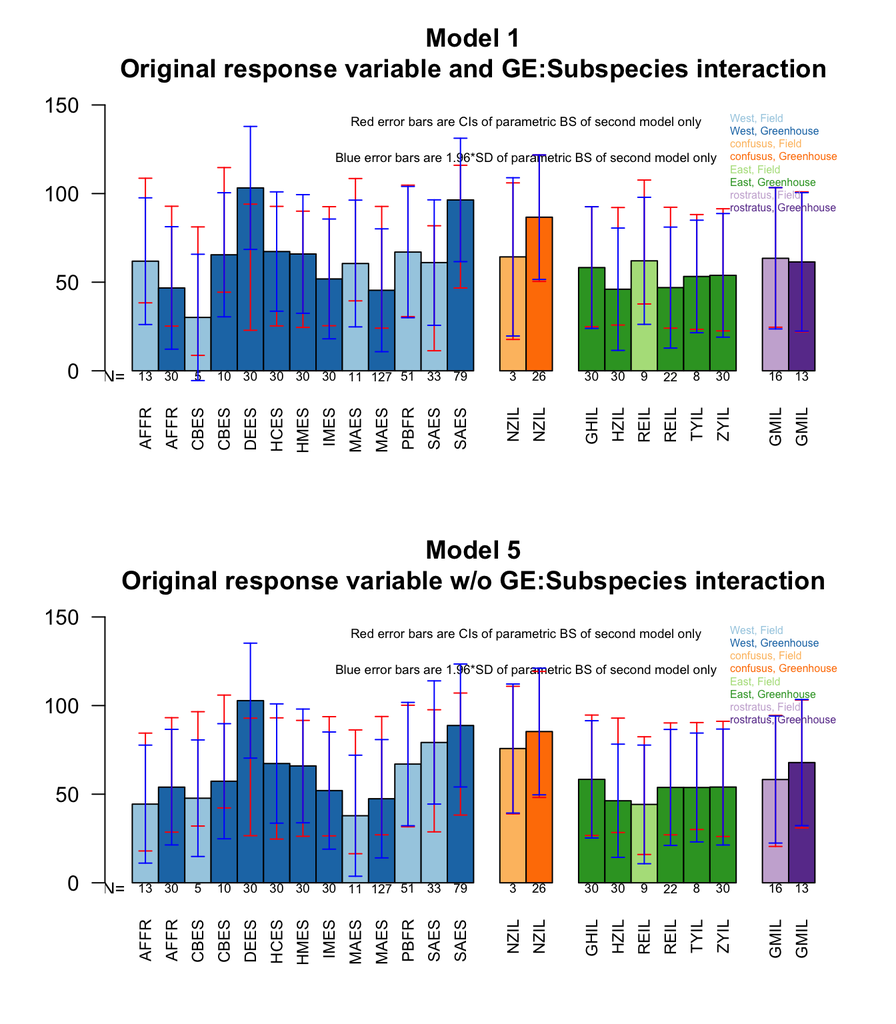

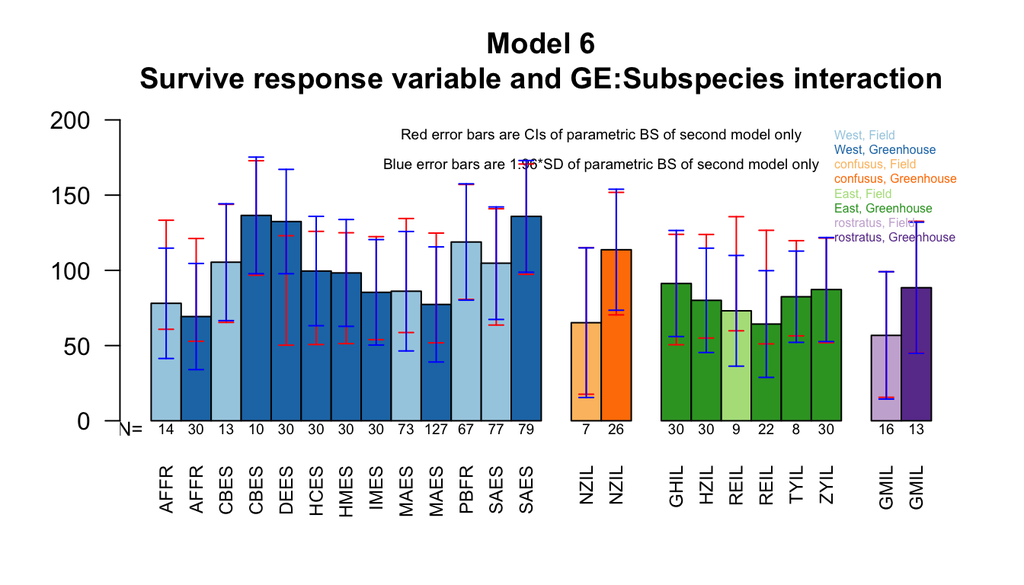

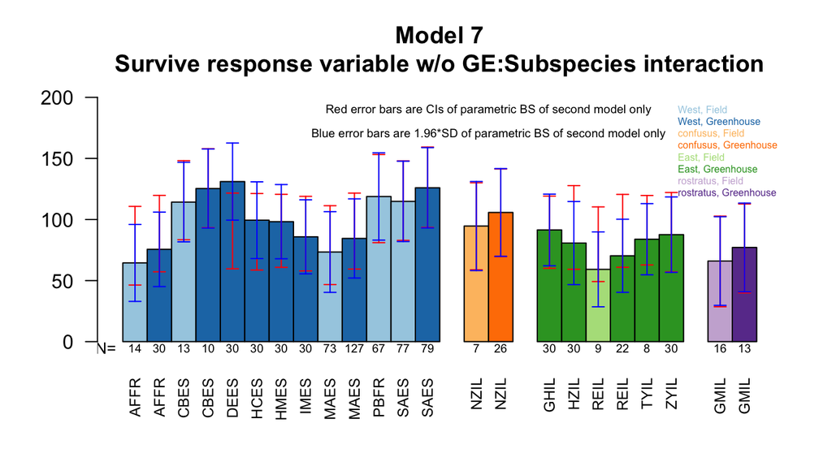

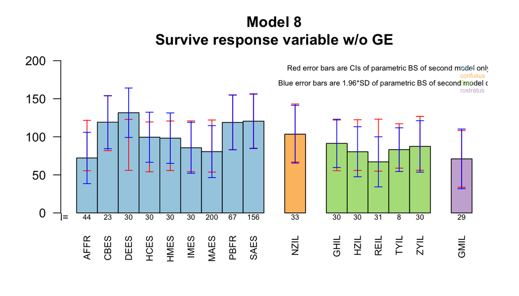

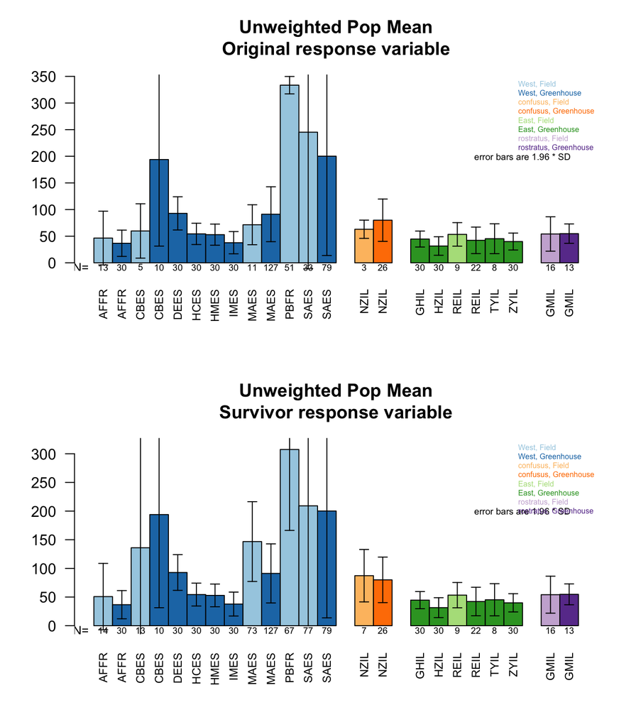